# Flood and Tornado are the most Detrimental Weather Events in U.S.

8/22/2020

### Synopsis

In this report, we aim to investigate the severity of extreme weather events in U.S. history. From NOAA Storm Data, we calculated the annual total casualties (fatality and injuries) and economic consequence (property damage and crop damage) for each extreme weather event. Based on our analysis, in the U.S., the weather event that is most harmful to public health is *Tornado*, and the one with greatest economic consequences is *Flood*. Furthermore, both flood and tornado occurrences are on the raise.

### Background

The [NOAA Storm Data](https://d396qusza40orc.cloudfront.net/repdata%2Fdata%2FStormData.csv.bz2) can be downloaded here.

The goal of this project is to study the NOAA Storm Database and answer:

1. Which type of weather event is most harmful to public health in U.S.?
2. Which type of weather event is most damaging to economy in U.S.?

### Data Processing

#### Reading Data

```r
library(tidyverse)
library(magrittr)
library(lattice)
library(knitr)
library(lubridate)
```

This portion of the code downloads the NOAA data and processes it

```r
filelink <- "https://d396qusza40orc.cloudfront.net/repdata%2Fdata%2FStormData.csv.bz2"

download.file(filelink,"StormData.csv.bz2", method = "curl")

stormdata <- read.csv("StormData.csv.bz2")

stormdata2 <- stormdata


## Data contain summaries as observations, i.e. obs. 278098 is "Summary: Nov. 16"
## The filter() function below removes these observations
stormdata2 <- stormdata2 %>%
  mutate(Time = sub(" 0:00:00", "", BGN_DATE)) %>%
  mutate(Time = as.POSIXct(Time,format = "%m/%d/%Y")) %>%
  select(Time,TIME_ZONE,STATE,EVTYPE,FATALITIES,INJURIES,
                                   PROPDMG,PROPDMGEXP,CROPDMG,CROPDMGEXP) %>%
  filter(!grepl("summary",stormdata2$EVTYPE,ignore.case = T)) %>%
  mutate(EVTYPE = as.factor(EVTYPE))

remove(stormdata) # Original data is removed for memory efficiency
```

#### Data Processing

The following section processes the storm data for calculations

```r
## Exponents of the economic damage are noted as "K", "M", "B", etc.
## The following lines converts it to numeric representations

exponents <- unique(c(stormdata2$PROPDMGEXP,stormdata2$CROPDMGEXP))
exp_value <- 10**c(3,6,0,9,6,NA,0,5,6,NA,4,2,3,NA,7,NA,NA,1,8,3)

## unknown exponents like "+", "?", "h", "H", or "-" were also introduced in the data
## For the purpose of this study, they are assumed to be NA
## k, K == 1000; m, M == 10**6; B == 10**9; 7 == 10** 7 etc

stormdata2$CROPDMGEXP[stormdata2$CROPDMGEXP %in% exponents] <- exp_value[match(
  stormdata2$CROPDMGEXP,exponents, nomatch = NA
)]

stormdata2$PROPDMGEXP[stormdata2$PROPDMGEXP %in% exponents] <- exp_value[match(
  stormdata2$PROPDMGEXP,exponents, nomatch = NA
)]

stormdata2$PROPDMGEXP <- as.numeric(stormdata2$PROPDMGEXP)
stormdata2$CROPDMGEXP <- as.numeric(stormdata2$CROPDMGEXP)

## The total property damage PROPTOTAL and total crop damage CROPTOTAL are noted
## in the units of millions of dollars
stormdata2 <- stormdata2 %>%
  mutate(PROPTOTAL = PROPDMG * PROPDMGEXP/10**6,
         CROPTOTAL = CROPDMG * CROPDMGEXP/10**6, DAMAGETOTAL = CROPTOTAL + PROPTOTAL,
         CASUALTY = FATALITIES + INJURIES, YEAR = year(Time))
```

The following section calculates the casualty by weather events

```r
casualty <- stormdata2 %>% group_by(EVTYPE) %>%
  summarise(count = n(), Total_Fatality = sum(FATALITIES),
            Total_Injury = sum(INJURIES), Mean_Fatality = mean(FATALITIES),
            Mean_injury = mean(INJURIES),
            Total = Total_Fatality + Total_Injury,
            .groups = "drop_last") %>%
  ungroup() %>%
  arrange(desc(Total))
```

The following section calculates the damage by weather events

```r
## Damage is recorded in millions of dollars
damage <- stormdata2 %>% group_by(EVTYPE) %>%
  summarise(count = n(), Total_Property = sum(PROPTOTAL),
            Total_Crop = sum(CROPTOTAL), Mean_Property = mean(PROPTOTAL),
            Mean_Crop = mean(CROPTOTAL), Total = Total_Property + Total_Crop,
            .groups = "drop_last") %>%
  ungroup() %>%
  arrange(desc(Total))
```

#### Results

In the U.S., the weather event most harmful to public health is **TORNADO**, and the one with greatest economic consequences is **FLOOD**. To compute for the threat to public health, the total fatalities and total injuries are considered; for assessing economic damage, total property damage and total crop damage are added.

##### Result Table

```r
casualty_table <- head(casualty,3) %>%
  mutate(Ranking = row_number(), Event = EVTYPE) %>%
  select(Ranking, Event, Total_Injury, Total_Fatality, Total)


damage_table <- head(damage,3) %>%
  mutate(Ranking = row_number(), Event = EVTYPE) %>%
  select(Ranking, Event, Total_Property, Total_Crop,Total)

#Formatting the table by reducing line length
damage_table$Event <- gsub("/TYPHOON", "/ TYPHOON", damage_table$Event)

kables(list(
  kable(casualty_table, align = "c", caption = "Table 1. Weather Events with the most Casualty"),
  kable(damage_table, align = "c", caption = "Table 2. Weather Events with the most Economic Damage ($ Mil)")
))
```

Table 1. Weather Events with the most Casualty

| Ranking | Event | Total_Injury | Total_Fatality | Total |
| --- | --- | --- | --- | --- |
| 1 | TORNADO | 91346 | 5633 | 96979 |
| 2 | EXCESSIVE HEAT | 6525 | 1903 | 8428 |
| 3 | TSTM WIND | 6957 | 504 | 7461 |

Table 2. Weather Events with the most Economic Damage ($ Mil)

| Ranking | Event | Total_Property | Total_Crop | Total |
| --- | --- | --- | --- | --- |
| 1 | FLOOD | 144657.71 | 5661.968 | 150319.68 |
| 2 | HURRICANE/ TYPHOON | 69305.84 | 2607.873 | 71913.71 |
| 3 | STORM SURGE | 43323.54 | 0.005 | 43323.54 |

##### Plotting Weather Events by Time

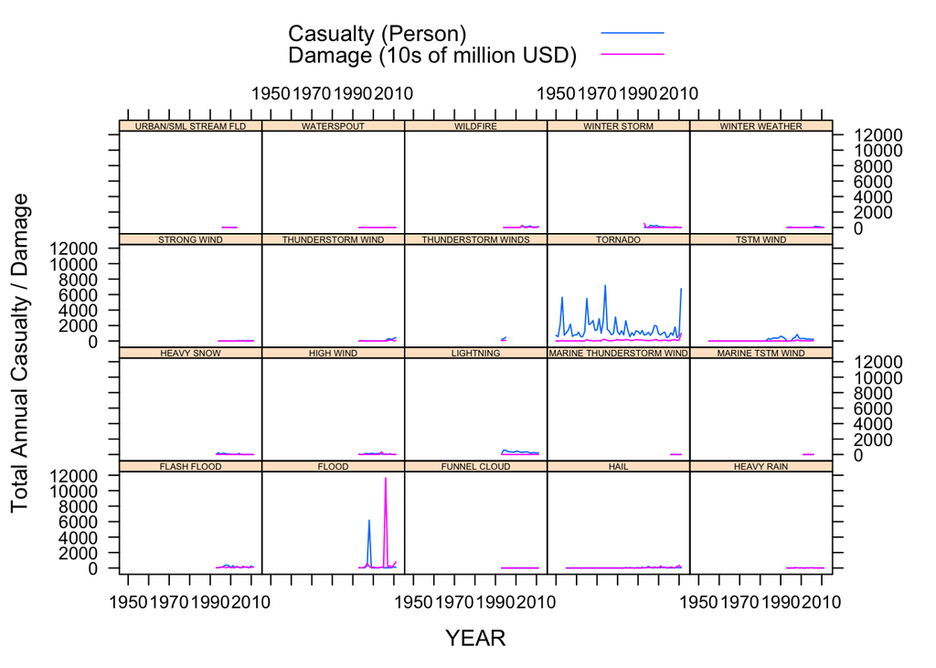

```r
plotting <- stormdata2 %>% group_by(EVTYPE) %>%
  mutate(Event_Count = n()) %>%
  arrange(desc(Event_Count))

most_freq <- as.character(unique(plotting$EVTYPE)[1:20])

plotting <- plotting %>%
  filter(EVTYPE %in% most_freq) %>%
  mutate(EVTYPE = droplevels(EVTYPE)) %>%
  select(Time, YEAR, STATE, EVTYPE, CASUALTY, DAMAGETOTAL)

plotting <- plotting %>%
  group_by(EVTYPE,YEAR) %>%
  summarise(EVCOUNT = n(), CASUALTY_Y = sum(CASUALTY,na.rm = T),
            DAMAGE_Y = sum(DAMAGETOTAL,na.rm = T),
            .groups = "drop_last") %>%
  ungroup()

xyplot(CASUALTY_Y + DAMAGE_Y/10 ~ YEAR | EVTYPE, plotting, type = "l",
       par.strip.text = list(cex = 0.4),
       auto.key = list(space = "top", points = F, lines = T,
                       text = c("Casualty (Person)", "Damage (10s of million USD)")),
       ylab = "Total Annual Casualty / Damage")
```

Figure 1. The panel plot shows the total annual casualty *(shown in blue)* and the total economic damage *(shown in magenta)* for the 20 most frequent extreme weather events from 1950 to 2011

##### Plotting Occurance Trend for Flood and Tornado

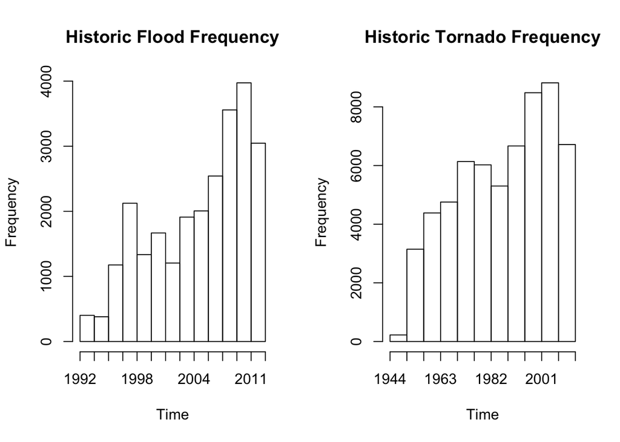

```r
par(mfrow = c(1,2))
flood <- stormdata2[which(stormdata2$EVTYPE == "FLOOD"),]
hist(flood$Time, freq = T, breaks = 12, main = "Historic Flood Frequency",
     xlab = "Time")
tornado <- stormdata2[which(stormdata2$EVTYPE == "TORNADO"),]
tornado <- mutate(tornado, casualty = FATALITIES + INJURIES)
hist(tornado$Time, freq = T, breaks = 12, main = "Historic Tornado Frequency",
     xlab = "Time")
```

Figure 2. The histograms show the occurrence frequency for flood *(left)* and tornado *(right)* from available NOAA record